# Lab-04

Janish Parikh

31/08/2020

[link for codes](https://github.com/Ansh-Ji/CS-605-Data-Analytics-in-R/tree/master/Lab4) ## Loading the required Packages

```r
library('dplyr')
library('ggplot2')
library('statsr')
```

## Question -01

Refer to Example:1 in “12 DA CS605.pdf” class slides. Find a P-value for the right-tail test. What is your conclusion about a significant increase in the number of concurrent users?

We are given the following: 1.**The number of concurrent users for some ISP has always averaged 5000 with a standard deviation of 800.**

2. **After an equipment upgrade, the average number of users at 100 randomly selected moments of time is 5200.**

### H0 : population mean = 5000

### HA : population mean > 5000

```r
null_value<-5000 #population_mean
point_estimate<-5200 #observed extreme
sd<-800#standard deviaton
n<-100 #sample size
alpha<-0.05 #significance
condition<-qnorm(1-alpha)
```

### Checking Conditions:

1. -Independence - We can assume that the data is independent.
2. -Sample size (100) <10% of the population

### Drawing Sampling Distributions:

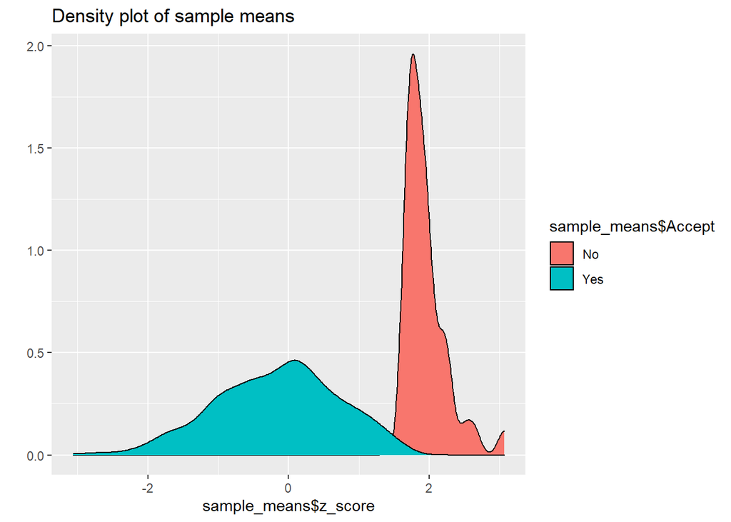

```r
sample_means = rep(NA, 1000)
for(i in 1:1000){
  sample_means[i] = mean(rnorm(n =100,mean = 5000, sd=800))
}
sample_means<-data.frame("data"=sample_means)
sample_means$z_score<- (sample_means$data-null_value)/(800/sqrt(n))
sample_means$Accept<-ifelse(sample_means$z_score<condition,"Yes","No")
sample_means$Accept<-factor(sample_means$Accept)
qplot(x=sample_means$z_score, fill = sample_means$Accept,geom = 'density',
      main='Density plot of sample means')
```

### Calculationg Test Statistic

```r
test_statistic<-(point_estimate-null_value)/(sd/sqrt(n))
```

### Drawing the plot and shading the P- value

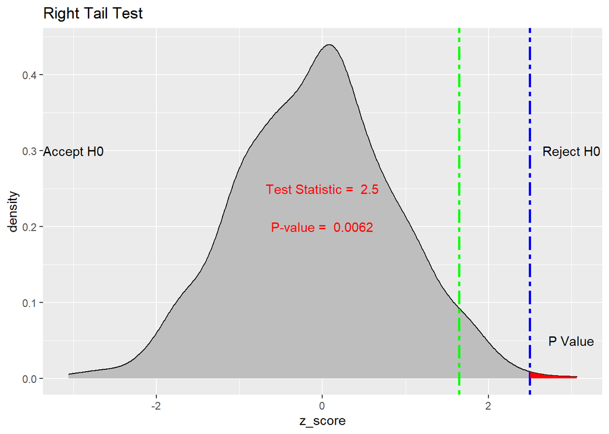

```r
#P-Value is the area under red color
p_value<-1-pnorm(test_statistic, mean=0, sd=1)
p_value<-round(p_value,digits=4)

ggplot() +
  geom_density(data=sample_means, aes(x=z_score), fill='grey') +
  geom_vline(data=sample_means,
             aes(xintercept=test_statistic),
             colour="blue", linetype=6, size=1) +
   geom_vline(data=sample_means,
             aes(xintercept=condition),
             colour="green", linetype=6, size=1) +
  ggtitle("Right Tail Test") -> density_plot

dpb <- ggplot_build(density_plot )
x1 <- min(which(dpb$data[[1]]$x >=test_statistic))
x2 <- max(which(dpb$data[[1]]$x <=10))
density_plot +
  geom_area(data=data.frame(x=dpb$data[[1]]$x[x1:x2],
                       y=dpb$data[[1]]$y[x1:x2]),
            aes(x=x, y=y), fill="red")+annotate(geom="text", x=0, y=0.2,
            label=paste("P-value = ",p_value),color="red")+
            annotate(geom="text", x=0, y=0.25,
            label=paste("Test Statistic = ",test_statistic),color="red")+
            annotate(geom="text", x=-3, y=0.3, label="Accept H0")+
            annotate(geom="text", x=3, y=0.3, label="Reject H0")+
            annotate(geom="text", x=test_statistic+0.5, y=0.05, label="P Value")
```

```r
rm(list = ls())
```

### Conclusion

If we infer to reject from significance level of 5% then we can be 90% sure that the null_value will not be in the 90% confidence interval As the P-Value is very very low, we can say that the P(Observed or extreme outcome| H0 is true) is low enough to reject H0 We can say from the results inferred from Right -Tail Test that we can agree that there’s a significant increase in the no of concurrent users

## Question -02

A sample of 250 items from lot A contains 10 defective items, and a sample of 300 items from lot B is found to contain 18 defective items.

```r
prop_a<-10/250
prop_b<-18/300
#Theses are Bernoulli data i.e. only two outcomes defective or not
#Sucess defined as getting a defective piece
```

### 1. Implement a 98% confidence interval for the difference of proportions of defective items.

```r
alpha<-0.02 #98% confidence interval
point_estimate<-prop_b-prop_a # sample proportions
standard_error<-sqrt(prop_a*(1-prop_a)/250+prop_b*(1-prop_b)/300) #standard error of sampling distribution
#Confidence Interval = point estimate +- margin of error
margin_of_error<-qnorm(1-alpha/2)*standard_error
Lower=point_estimate-margin_of_error
Upper = point_estimate+margin_of_error
confidence_level<-c(Lower,Upper)
print(confidence_level)
```

```
## [1] -0.02299655  0.06299655
```

### Plotting the Confidence Interval

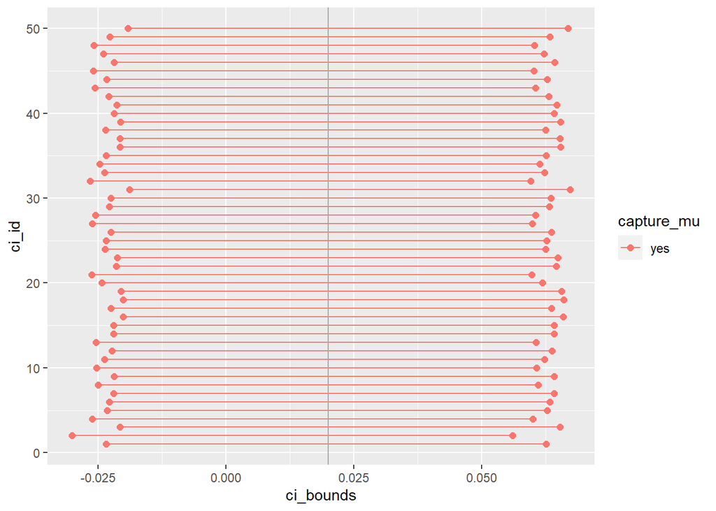

```r
data1<-data.frame(data=rnorm(100000,mean=point_estimate, sd=standard_error))
ci<-data1 %>%
        rep_sample_n(size = 50, reps = 50, replace = TRUE) %>%
        summarise(lower = mean(data) -  margin_of_error,
                  upper = mean(data) + margin_of_error)
ci <- ci %>%
  mutate(capture_mu = ifelse(lower < point_estimate & upper > point_estimate, "yes", "no"))
ci_data <- data.frame(ci_id = c(1:50, 1:50),
                      ci_bounds = c(ci$lower, ci$upper),
                      capture_mu = c(ci$capture_mu, ci$capture_mu))
ggplot(data = ci_data, aes(x = ci_bounds, y = ci_id,
                           group = ci_id, color = capture_mu)) +
  geom_point(size = 2) +  # add points at the ends, size = 2
  geom_line() +           # connect with lines
  geom_vline(xintercept = point_estimate, color = "darkgray") # draw vertical line
```

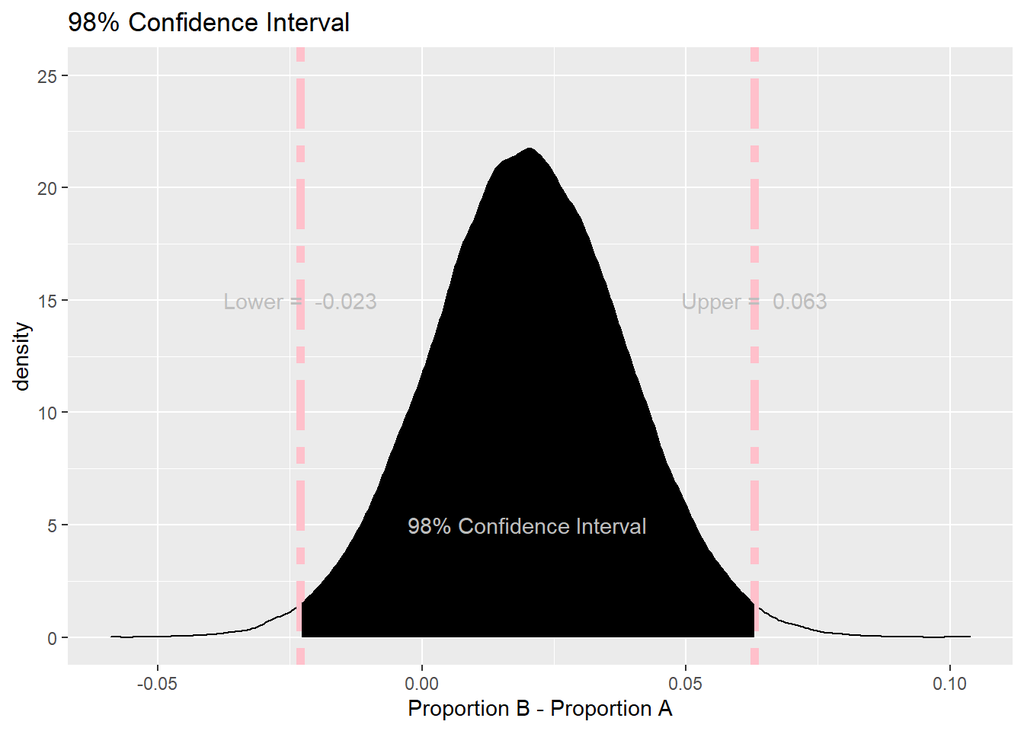

```r
density_plot1<-ggplot(data1)+
               geom_density(aes(x=data))+
               geom_vline(xintercept=Lower, colour="pink", linetype=6, size=2) +
               geom_vline(xintercept=Upper, colour="pink", linetype=6, size=2) +
               ylim(0,25)+
               labs(x="Proportion B - Proportion A")+
               ggtitle("98% Confidence Interval")

dpb <- ggplot_build(density_plot1 )
x1 <- min(which(dpb$data[[1]]$x >=Lower))
x2 <- max(which(dpb$data[[1]]$x <=Upper))
density_plot1 +geom_area(data=data.frame(x=dpb$data[[1]]$x[x1:x2],y=dpb$data[[1]]$y[x1:x2]),
                         aes(x=x, y=y), fill="black")+
               annotate(geom="text", x=Lower, y=15,
                        label=paste("Lower = ",round(Lower,3)), color="grey")+
               annotate(geom="text", x=Upper, y=15,
               label=paste("Upper = ",round(Upper,3)),color="grey")+
               annotate(geom="text", x=point_estimate, y=5,
                        label="98% Confidence Interval", color="grey")
```

### 2.At a significance level α = 0.02, is there a significant difference between the quality of the two lots?

### H0 : pa=pb

### HA : pa !=pb

### Calculating Test Statistic

```r
# The test statistic can be derived as
null_value<-28/550 #Pooled proportion
alpha<-0.02 #significance level
standard_error_hypothesis<-sqrt(null_value*(1-null_value)*(1/250 + 1/300))

test_statistic<-point_estimate/standard_error_hypothesis

p_value<-(1-pnorm(test_statistic))*2 #Area as shaded under the graph
```

### Drawing the plot and shading the P- value

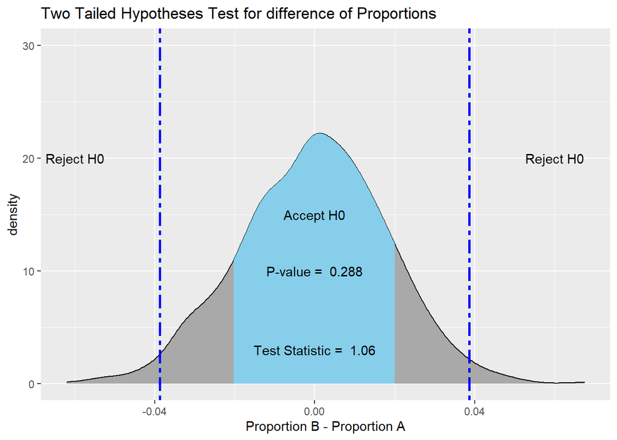

```r
condition<-qnorm(1-alpha)
data2<-data.frame(data=rnorm(1000,mean = 0,sd=standard_error_hypothesis))

density_plot1<-ggplot(data2)+
               geom_density(aes(x=data), fill ="dark grey")+
               #geom_vline(xintercept=point_estimate, colour="pink", linetype=6) +
               #geom_vline(xintercept=-point_estimate, colour="pink", linetype=6) +
               ylim(0,30)+
               geom_vline(data=data2, aes(xintercept=-condition*standard_error_hypothesis),
                          colour="blue", linetype=6, size=1)+
               geom_vline(data=data2, aes(xintercept=condition*standard_error_hypothesis),
                          colour="blue", linetype=6, size=1)+
               labs(x="Proportion B - Proportion A")+
               ggtitle("Two Tailed Hypotheses Test for difference of Proportions")


dpb <- ggplot_build(density_plot1 )
x1 <- min(which(dpb$data[[1]]$x >=point_estimate))
x2 <- max(which(dpb$data[[1]]$x <=-point_estimate))
density_plot1 +geom_area(data=data.frame(x=dpb$data[[1]]$x[x1:x2],y=dpb$data[[1]]$y[x1:x2]),
                         aes(x=x, y=y), fill="sky  blue")+
               annotate(geom="text", x=0, y=10,
                        label=paste("P-value = ",round(p_value,3)))+
               annotate(geom="text", x=0, y=3,
                        label=paste("Test Statistic = ",round(test_statistic,2)))+
               annotate(geom="text", x=0, y=15, label="Accept H0")+
               annotate(geom="text", x=-0.06, y=20, label="Reject H0")+
               annotate(geom="text", x=0.06, y=20, label="Reject H0")
```

```r
rm(list = ls())
```

## Question -03

Ram says to Shyam that he is a stronger student because his average grade for the first six quizzes is higher. However, Shyam replies that he is more stable student because the variance of his grades is lower. The scores are independent and normally distributed

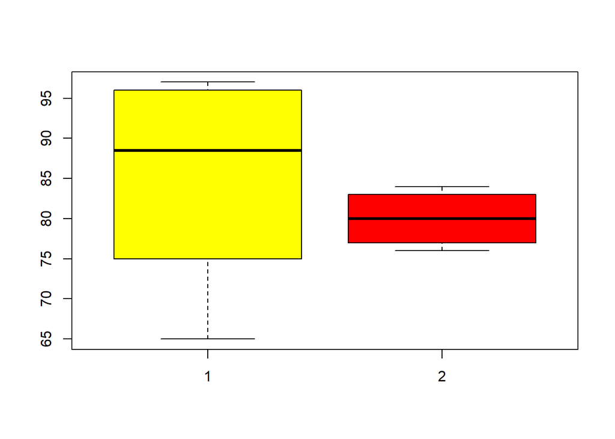

```r
ram<-c(85,92,97,65,75,96)
shyam<-c(81,79,76,84,83,77)
data<-data.frame(cbind(ram,shyam))
avg_score_ram<-mean(data$ram)
avg_score_shyam<-mean(data$shyam)
boxplot(ram,shyam,col=c("yellow","red"))
```

### 3-1

```r
null_value<-0
point_estimate<-5200
sd<-800#standard deviation
n<-100 #sample size
alpha<-0.05 #significance
condition<-qnorm(1-alpha)
t.test(ram,shyam, alternative = "greater", var.equal = F)
```

```
##
##  Welch Two Sample t-test
##
## data:  ram and shyam
## t = 0.93062, df = 5.6362, p-value = 0.1951
## alternative hypothesis: true difference in means is greater than 0
## 95 percent confidence interval:
##  -5.56219      Inf
## sample estimates:
## mean of x mean of y
##        85        80
```

### Conclusion

- The *p-value 0.1951* is greater than the alpha = .05 level of significance.
- We don’t have enough evidence to reject H0 that average score of Ram is same as that of average score of Shyam
- This may be because, we have very less data resulting in a higher standard error

### 3-2

```r
data_ram<-sample_n(data,1000, replace = T)%>%summarise(var=var(data))

var<-data %>%
        rep_sample_n(size = 6, reps = 10000, replace = TRUE) %>%
        summarise(var_ram =var(ram),var_shyam = var(shyam))
t.test(var$var_shyam,var$var_ram, var.equal = F)
```

```
##
##  Welch Two Sample t-test
##
## data:  var$var_shyam and var$var_ram
## t = -204.61, df = 10057, p-value < 2.2e-16
## alternative hypothesis: true difference in means is not equal to 0
## 95 percent confidence interval:
##  -128.8109 -126.3663
## sample estimates:
## mean of x mean of y
##   8.69806 136.28669
```

### Conclusion

- The *p-value 2.2e-16* is much lower than the alpha = .05 level of significance.
- We have enough evidence to reject H0 that Ram’s score are as stable as that of Shyam’score